# An Analysis of the Relationship between Suicide Incidences and Suicide-related Media Coverage

Haruto Yano

2023-05-12

## 1 Introduction

This is a data analysis project in Macro Data Science class when I was a junior. In this project, I explore correlation between fluctuation in suicide and media report on suicide using data in Japan. There’s been phenomena that we find increase in suicide after media reports suicide of celebrity. This is called [“Werther effect”](https://ja.wikipedia.org/wiki/%E3%82%A6%E3%82%A7%E3%83%AB%E3%83%86%E3%83%AB%E5%8A%B9%E6%9E%9C) or “Copycat suicide”. Especially, during covid-19 pandemic, we saw increase in suicide and some of them were reported by media. If we actually can observe the phenomenon, then policy maker and mass media have to take some measure to prevent news report from inducing suicide. My purpose here is to make it clear that whether we can find “Werther effect”. If you are not familier with time series data analysis, [this paper](https://www.sciencedirect.com/science/article/pii/S2405918817300405) helps you understand time series analysis briefly.

## 2 Data

I used the number of suicide data, Covid-19 confirmed case data from MHLW and unemployment rate data from MIC.

- [Suicide data](https://www.mhlw.go.jp/stf/seisakunitsuite/bunya/0000140901.html)
- [Covid-19 data](https://www.mhlw.go.jp/stf/covid-19/open-data.html)
- [Unemployment data](https://www.stat.go.jp/data/roudou/longtime/03roudou.html#hyo_1)

Unemployment rate has been considered to be correlated with suicide rate. During recession period, unemployment rate rises and suicide rate rises accordingly. The reason I selected the number of Covid-19 case is that it correlated with period of state of emergency and during this period, some suicide cases were reported on the media.

### 2.1 Descriptive Statistics

The table below is summary of data. The data I use contains the number of suicide for each generations and gender, unemployment rate for men and women, and the number of confirmed case of covid-19 from 2013 to 2022. All of data is log-transformed.
$$\text{Descriptive Statistics}$$

[interactive chart not shown]

### 2.2 Visualization

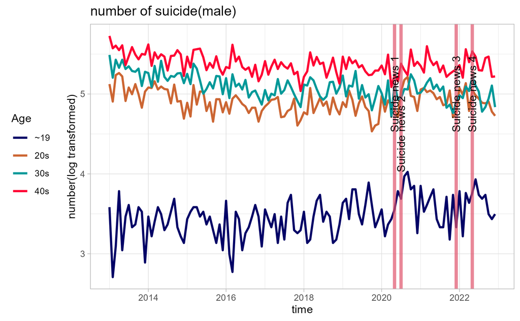

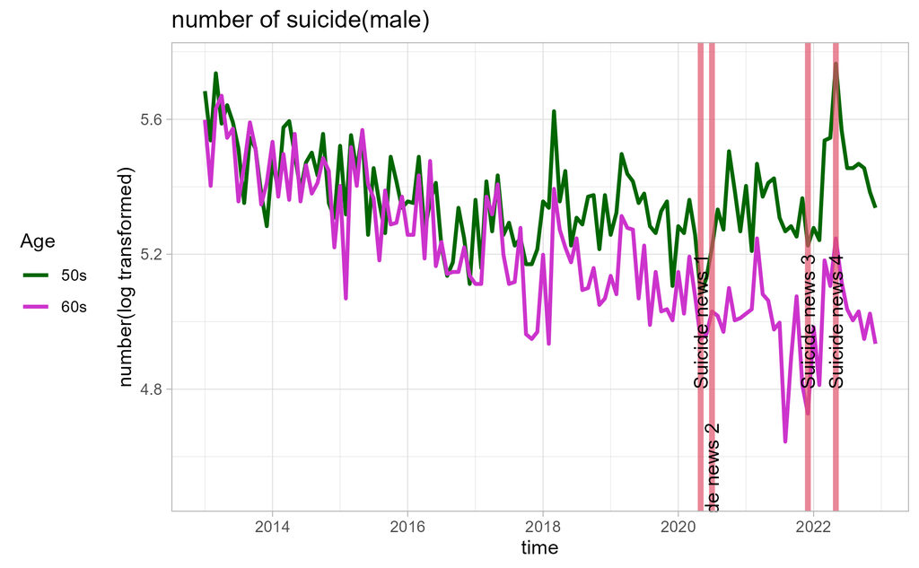

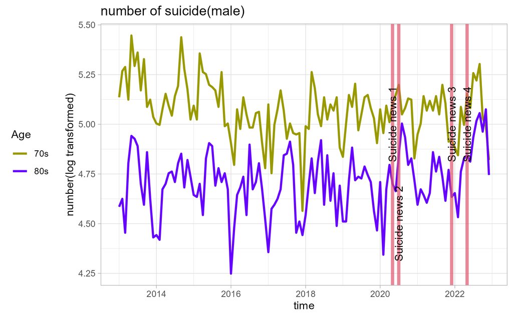

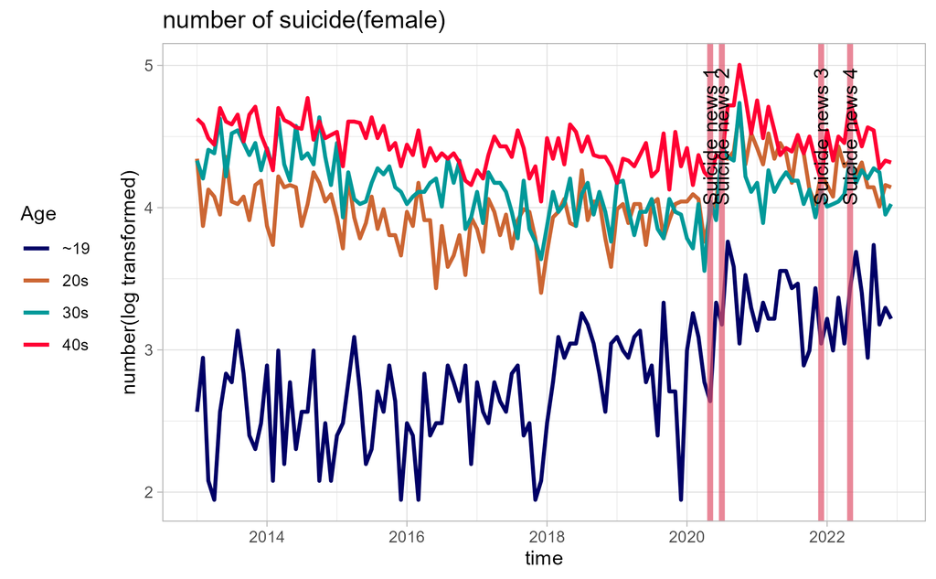

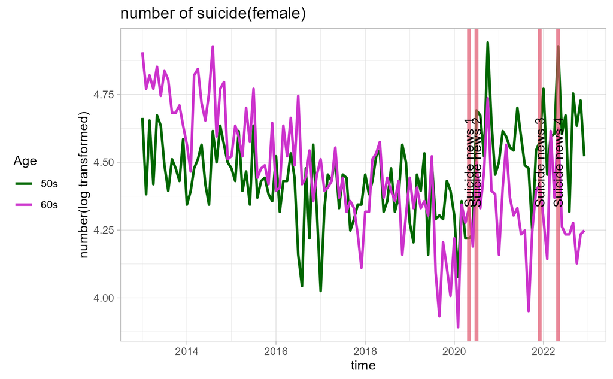

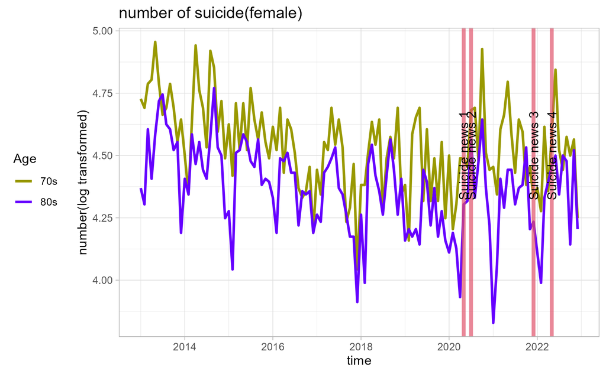

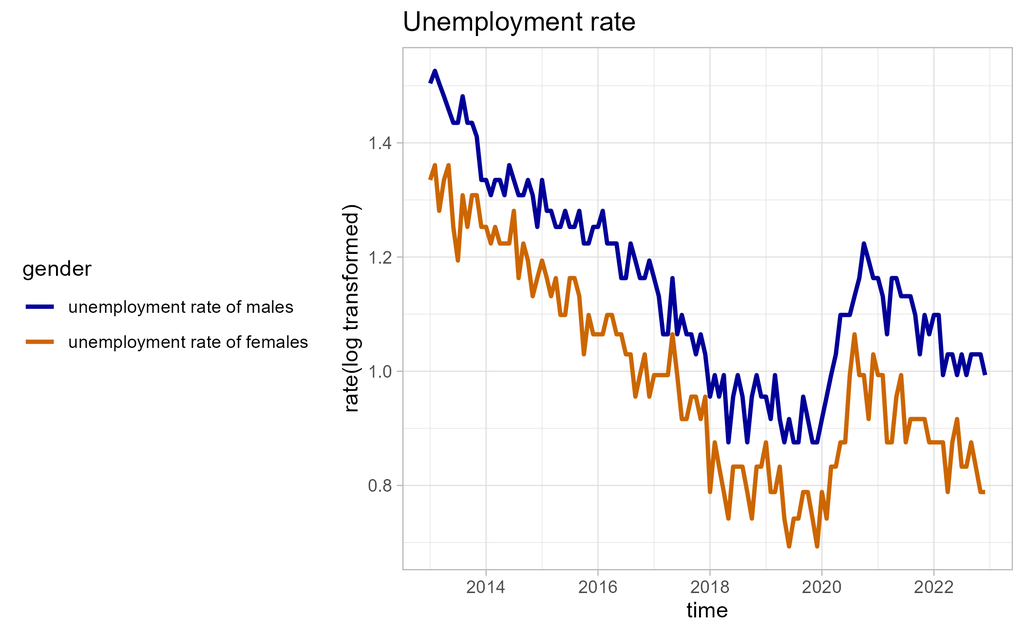

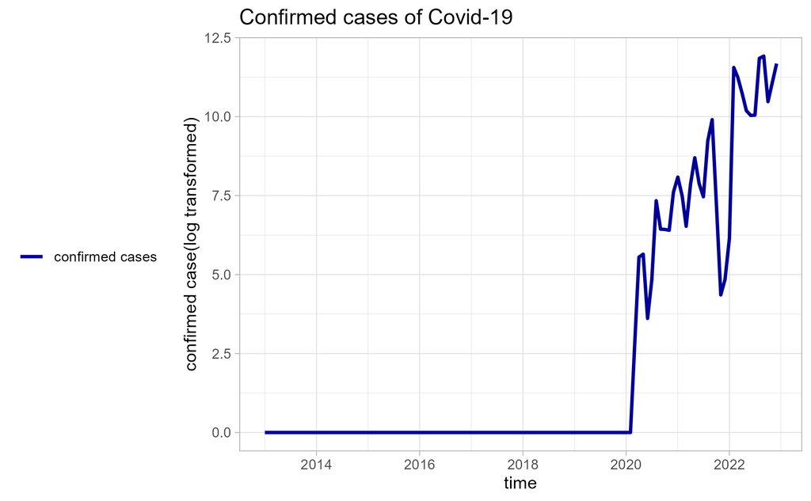

### 2.3 Unit root test

We have to check whether each time series data has unit root. If a time series data has unit root, the data is called non-stationary. Estimating on non-stationary data leads to spurious relationship, so we need to distinguish stationary and non-stationary data. ADF, PP and KPSS are popular unit root test. As you can see in graph, some time series data potentially have structural break, which make it difficult to detect unit root correctly. So I tested unit root with Zivot-Andrew test that can take an effect of single structural break into account. Most of the ADF test,PP test and KPSS test results contradict each other especially in men’s suicide data. Here, I prioritize ADF test result and I confirmed data of woman under 19 yaers old as I(1).

[interactive chart not shown]

## 3 Model

As for study of suicide, you can choose different empirical models depending on your purpose. In this report, I adopted ARDL model because it can include both endogenous and exogenous variables with their lags and allow I(1) data to be included. The model is given by:
$$ln(S_{i,j,t}) = \alpha + \sum_{p=1}^{P} \beta_p ln(S_{i,j,t-p}) +
\sum_{q=0}^{Q} \gamma_q ln(U_{i,t-q})+ \sum_{r=0}^{R} \delta_r
ln(C_{t-r}) + \lambda_1 news_t + \lambda_2 month_t + \lambda_3 trend
+ \epsilon_t$$
where

- i,j,t represent gender, age, period respectively
- S is the number of suicide
- U is Unemployment rate
- C is infection count
- news is dummy for suicide reports
- As a monthly dummy, I incorporated March and April dummy because in Japan, suicide case increases in spring. Look [this site](https://ja.wikipedia.org/wiki/%E6%97%A5%E6%9C%AC%E3%81%AB%E3%81%8A%E3%81%91%E3%82%8B%E8%87%AA%E6%AE%BA)

The error correction model is given by:
$$\Delta ln(S_{i,j,t}) = \alpha + \sum_{p=1}^{P} \Delta \beta_p
ln(S_{i,j,t-p}) + \sum_{q=0}^{Q} \gamma_q \Delta ln(U_{i,t-q})+
\sum_{r=0}^{R} \delta_r \Delta ln(C_{t-r}) + \theta_0 ln(S_{i,j,t-1}) +
\theta_1 ln(U_{i,t-1}) + \theta_2 ln(C_{t-1}) + \lambda_1 news_t +
\lambda_2 month_t + \lambda_3 trend + \epsilon_t$$

## 4 Result

### 4.1 Estimation result

I pick up only results where I can find 5% significance in suicide report dummy, which are 20s,30s,50s of men and 20s,40s,50s and 60s of women’ results. Although I could find correlation between suicide and suicide news, we must be careful to interpret the results. Looking at diagnostic test in Appendix, you can find model of “wom_20s” doesn`t pass normality test, model of “man_50s” doesn’t pass serial correlation test, which means there’s room for improvement in model specification. Moreover, coefficient of suicide_report1 in “man_50s”, suicide_report3 in “wom_40s” are negative with significance and it’s hard to explain these results.

[interactive chart not shown]

### 4.2 Simulation

This is visualization of simulation that how much the suicide reports have an effect on suicide and how its effect lingers on.

#### **Effect of suicide report4 on man 20s ***

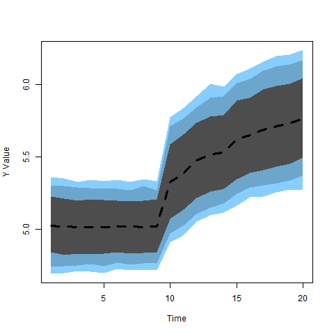

#### **Effect of suicide report4 on man 30s ***

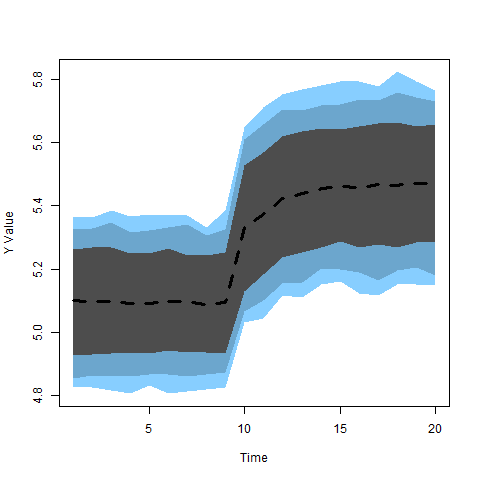

#### **Effect of suicide report1 on man 50s ***

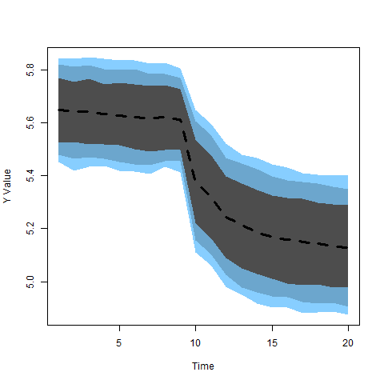

#### **Effect of suicide report4 on man 50s ***

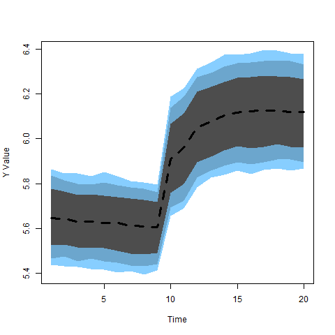

#### **Effect of suicide report2 on wom 20s ***

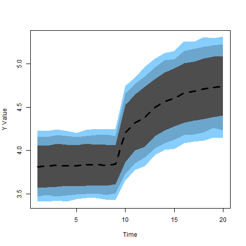

#### **Effect of suicide report3 on wom 40s ***

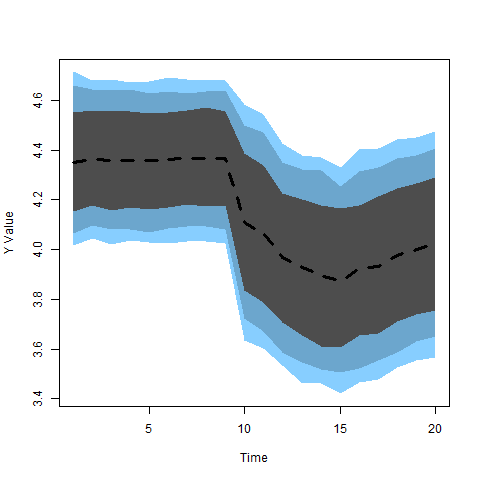

#### **Effect of suicide report4 on wom 40s ***

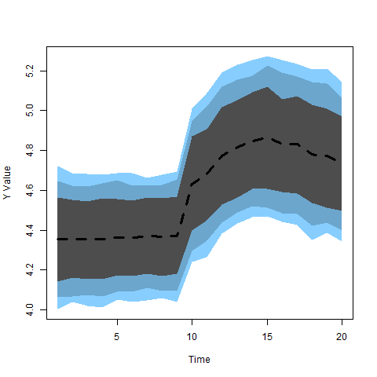

#### **Effect of suicide report4 on wom 50s ***

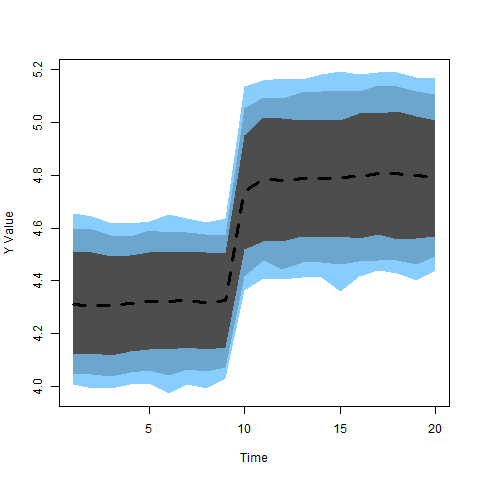

#### **Effect of suicide report2 on wom 60s ***

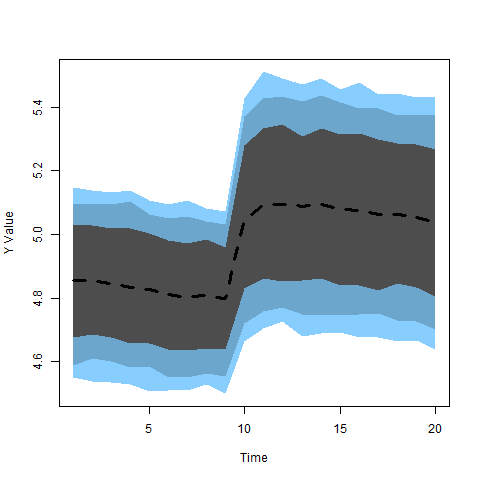

#### **Effect of suicide report4 on wom 60s ***

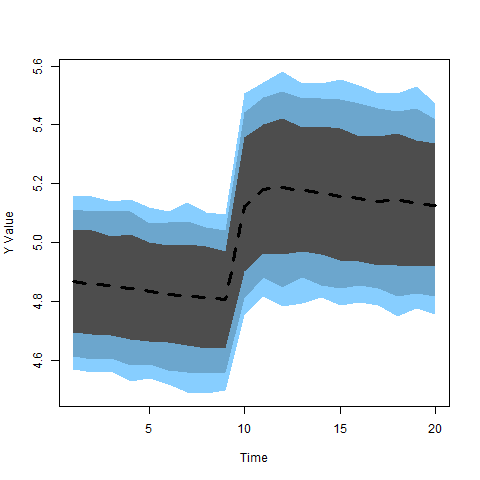

## 5 Discussion

Although I could observe correlations between the number of suicide and media coverage on suicide, as I mentioned in section 4.1, there’s issue in interpreting the result.

### 5.1 Choice of variables

One of the possible reason is that I incorrectly chose variables. For example, Covid-19 made it difficult to have interaction with people, which in turn worsen mental health of people. Considering that, I should have added pedestrian flow data as an index of people’s interaction. That said, I believe the number of infections in part correlate with people’s flow. Other than this, I had better have data about disease, which is one of the biggest reason for suicide or data about firm’s bankruptcy.